# Individual Project 3

Jie Zhou

# Report

## Part 1: Summary

```
   id Age Gender Income    Region                    Persona      Product
1:  1  57   Male  85000 Northeast    Materialistic Meditator Smartophonic
2:  2  67 Female  38000   Midwest        Outdoorsy Ombudsman Smartophonic
3:  3  55   Male  77000 Northeast   Precociously Preoccupied Smartophonic
4:  4  58   Male  47000     South      Ambivalent Adventurer Smartophonic
5:  5  70 Female  76000     South   Precociously Preoccupied Smartophonic
6:  6  58 Female 128000      West Technological Triumphalist Smartophonic
   Awareness BP_User_Friendly_0_10 BP_Fast_0_10 BP_Battery_Life_0_10
1:         0                    NA           NA                   NA
2:         0                    NA           NA                   NA
3:         0                    NA           NA                   NA
4:         0                    NA           NA                   NA
5:         1                     5            6                    7
6:         1                     8           10                    6
   BP_Camera_0_10 BP_Sleek_0_10 BP_Stylish_0_10 BP_Status_Symbol_0_10
```

[output cut: 20 more lines]

```
     Number of Products Number of respondents
[1,]                 20                 10000
```

This dataset contains 10,000 survey respondents, 20 products asked, and 3 various types of information, including

```
  "Demographic information" of survey respondents:
             age, gender, income, region, persona, and the specific product they purchased,

  "Product engagement" of respondents:
            whether aware of the product , whether considering buying the product, whether they consume the
            product, the satisfaction level (0-10), and whether advocating the product,

  and "Product/brand perception" of respondents:
   user friendliness, fast, battery life, camera, sleek, stylish, status symbol, screen size, boring, bulky,
   fragile,and expensive. Their ratings about products are stored in the range of 0 (bad)-10 (good).
```

To do the further analysis, consultants are able to divide data into various segments based on the demographic information, like region and persona, and determine which product has the best performance by various types of ratings, the significant relationship between respondents’ demographic information and their ratings, and how many respondents who are aware of this product have not purchased.

## Part 2: Specific Questions

### Q1: Resopendent Variables

#### Age Group

|  | age_group | Percentage of Respondents |
| --- | --- | --- |
| 1 | 18-35 | 31.12% |
| 2 | 35-50 | 26.92% |
| 3 | 50-65 | 27.08% |
| 4 | 65+ | 14.88% |

#### Gender

|  | Gender | Percentage of Respondents |
| --- | --- | --- |
| 1 | Female | 53.36% |
| 2 | Male | 46.64% |

#### Income Group

|  | Income Group | Percentage of Respondents |
| --- | --- | --- |
| 1 | $100,000-150,000 | 22% |
| 2 | $50,000-75,000 | 15.48% |
| 3 | $75,000-100,000 | 21.21% |
| 4 | &lt;$50,000 | 32.71% |
| 5 | &gt;$150,000 | 8.6% |

#### Region

|  | Region | Percentage of Respondents |
| --- | --- | --- |
| 1 | Midwest | 26.18% |
| 2 | Northeast | 25.62% |
| 3 | South | 24.08% |
| 4 | West | 24.12% |

#### Persona

|  | Persona | Percentage of Respondents |
| --- | --- | --- |
| 1 | Ambivalent Adventurer | 24.5% |
| 2 | Consistent Compromiser | 17.2% |
| 3 | Materialistic Meditator | 11.5% |
| 4 | Outdoorsy Ombudsman | 14.06% |
| 5 | Precociously Preoccupied | 9.34% |
| 6 | Technological Triumphalist | 23.4% |

### Q2: Segmented Outcomes

#### Part A

What are the top 5 products by Awareness rates in the Northeast?

|  | Product | Awareness Score |
| --- | --- | --- |
| 1 | Maybe Mobile | 84.74 % |
| 2 | Mobile Mayhem | 79.04 % |
| 3 | Next Text | 73.77 % |
| 4 | App Map | 72.87 % |
| 5 | Buzzdial | 71.04 % |

#### Part B

What are the top 5 products by Advocacy rates among females who earn at least $100,000?

```
           Product Advocacy Score
1: Communic Nation         100.00
2:    Smartophonic          87.80
3:   Mobile Mayhem          85.25
4:       Next Text          85.16
5:      Triumphone          77.78
```

### Q3: Overall Brand Perceptions

What are the top 5 brands by the overall average perception?

|  | Product | Overall Average Perception |
| --- | --- | --- |
| 1 | Screenz | 7.2077 |
| 2 | Cellularity | 6.3898 |
| 3 | Next Text | 6.3291 |
| 4 | No Buttons | 6.2353 |
| 5 | Smartophonic | 6.1029 |

### Q4: Gaps in Outcomes

#### Part A

Which 5 products have the largest gap between the rate of consumption and the rate of awareness?

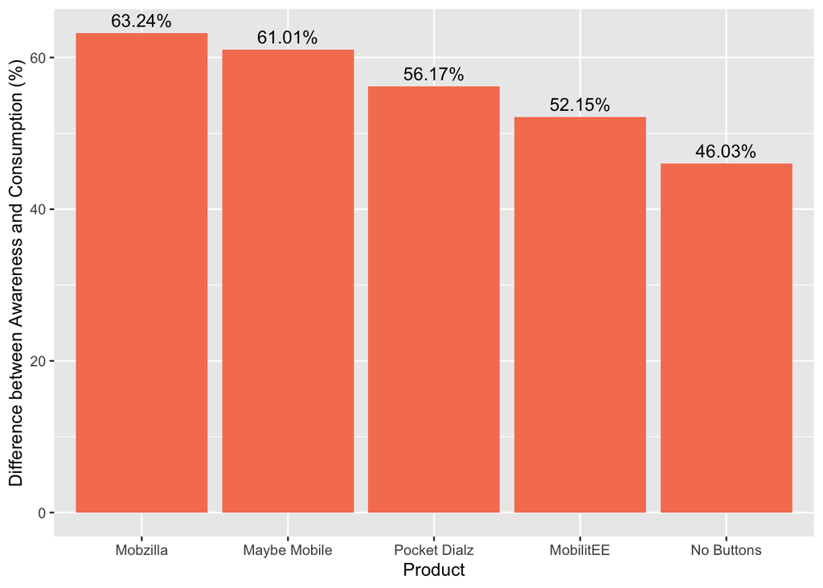

#### Part B

Which 5 products have the largest gap between the rate of Awareness and the average Satisfaction?

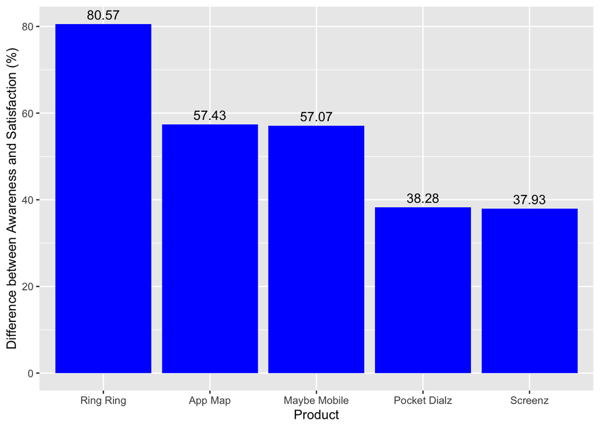

### Q5: Aggregated Engagement

#### Part A

How much impact does respondent’s overall trends in awareness have for that person’s awareness with Buzzdial phones?

|  | Odds ratio | 2.5 % | 97.5 % | P values |
| --- | --- | --- | --- | --- |
| (Intercept) | 1.3636 | 1.0676 | 1.7422 | 0.013 |
| age_group35-50 | 1.8091 | 1.6201 | 2.0211 | 0 |
| age_group50-65 | 0.8783 | 0.7908 | 0.9755 | 0.0154 |
| age_group65+ | 1.2748 | 1.1215 | 1.4499 | 0.0002 |
| GenderMale | 0.8636 | 0.7952 | 0.9378 | 0.0005 |
| `Income Group`&gt;$150,000 | 0.8803 | 0.7532 | 1.0295 | 0.1096 |
| `Income Group`$100,000-150,000 | 0.9268 | 0.8278 | 1.0379 | 0.1879 |
| `Income Group`$50,000-75,000 | 0.9193 | 0.8105 | 1.043 | 0.191 |
| `Income Group`$75,000-100,000 | 0.9708 | 0.8658 | 1.0887 | 0.6118 |
| aggregated_engagement | 0.7646 | 0.495 | 1.1809 | 0.2261 |

[output cut: 8 more lines]

#### Part B

How much impact does respondent’s overall trends in satisfaction have for that person’s satisfaction with Buzzdial phones?

|  | Coefficients | 2.5 % | 97.5 % | P values |
| --- | --- | --- | --- | --- |
| (Intercept) | 0.549 | 0.5126 | 0.5854 | 0 |
| age_group35-50 | 0.1337 | 0.109 | 0.1585 | 0 |
| age_group50-65 | -0.0316 | -0.0563 | -0.0068 | 0.0123 |
| age_group65+ | 0.0575 | 0.0277 | 0.0872 | 0.0002 |
| GenderMale | -0.0346 | -0.0535 | -0.0158 | 0.0003 |
| `Income Group`&gt;$150,000 | -0.0297 | -0.0657 | 0.0064 | 0.1065 |
| `Income Group`$100,000-150,000 | -0.0171 | -0.043 | 0.0088 | 0.1959 |
| `Income Group`$50,000-75,000 | -0.0194 | -0.0484 | 0.0097 | 0.1911 |
| `Income Group`$75,000-100,000 | -0.0066 | -0.0328 | 0.0196 | 0.6217 |
| aggregated_engagement | -0.0058 | -0.0447 | 0.033 | 0.768 |

[output cut: 8 more lines]